# Logic in Excel

Brendan Clarke, NHS Education for Scotland, brendan.clarke2@nhs.scot

13/11/2024

## Welcome

- this session is for 🌶🌶🌶 advanced Excel users, who are confident writing formulas
- if you can’t access the chat, you might need to join our Teams channel: [tinyurl.com/kindnetwork](https://teams.microsoft.com/l/team/19%3AQZ7-PbFVcziG2piHLt1_ifey3I2cwFL0yBuTSS8vVao1%40thread.tacv2/conversations?groupId=106d08f3-9026-40e2-b3c7-87cd87304d58&tenantId=10efe0bd-a030-4bca-809c-b5e6745e499a)
- you can find session materials at [tinyurl.com/kindtrp](https://nes-dew.github.io/KIND-training/)

## The KIND network

- a social learning space for staff working with **k**nowledge, **i**nformation, and **d**ata across health, social care, and housing in Scotland
- we offer social support, free training, mentoring, community events, …
- [Teams channel](https://teams.microsoft.com/l/team/19%3AQZ7-PbFVcziG2piHLt1_ifey3I2cwFL0yBuTSS8vVao1%40thread.tacv2/conversations?groupId=106d08f3-9026-40e2-b3c7-87cd87304d58&tenantId=10efe0bd-a030-4bca-809c-b5e6745e499a) / [mailing list](https://forms.office.com/pages/responsepage.aspx?id=veDvEDCgykuAnLXmdF5JmpopIZB9ynRJnrPUHVFccipURjM2NkZJUkhGOFlQRjQxRFhVUTgwT0UwVyQlQCN0PWcu)

## Session outline

- intro to logic in Excel
  - five minutes of Boolean algebra
  - basic logical functions (`NOT`, `AND`, `OR`)
  - putting logical functions to work with `IF` and `IFS`
- using logic in Excel
  - dealing with errors and missing values (`IFERROR`, `IFNA`, and friends)
  - managing different data types (`ISNUMBER` and friends)
  - conditional summarising (`SUMIF`, `COUNTIFS`, and friends)
  - nesting `IF` statements and future-proofing your work

## Boolean algebra

- the standard way of working with truth-values
  - found all over mathematics, logic, computer science…
- think of a statement like `"my cat is blue"`
  - call that `P` to save writing it every time
- assume that `P` is either completely `TRUE` or completely `FALSE`

## NOT

- `NOT` gives us the opposite truth-value
- if `P` is `FALSE`, then `NOT P` is `TRUE`
- a useful shorthand: the **truth table**:

| P | NOT P |
| --- | --- |
| TRUE | FALSE |
| FALSE | TRUE |

## AND

- we also have functions to understand what happens when we’re dealing with two statements
- `AND` is a great example - it’s `TRUE` when both the statements are `TRUE`

| P | Q | P AND Q |
| --- | --- | --- |
| TRUE | TRUE | TRUE |
| TRUE | FALSE | FALSE |
| FALSE | TRUE | FALSE |
| FALSE | FALSE | FALSE |

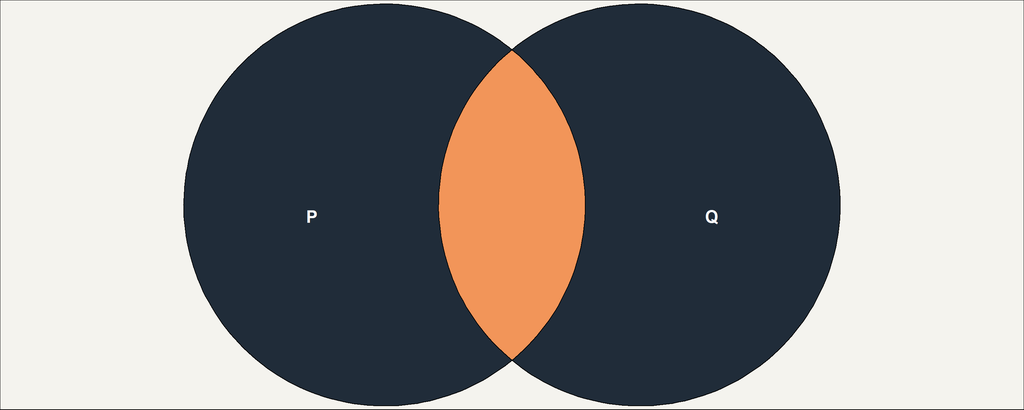

## OR

- `OR` is `TRUE` when either of the statements are `TRUE`

| P | Q | P OR Q |
| --- | --- | --- |
| TRUE | TRUE | TRUE |
| TRUE | FALSE | TRUE |
| FALSE | TRUE | TRUE |
| FALSE | FALSE | FALSE |

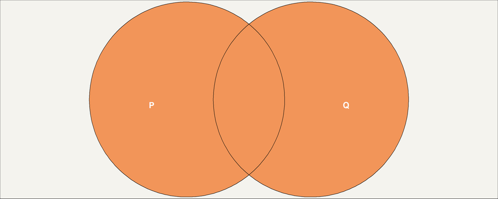

## XOR

- For completeness, we should also talk about `XOR`
- `XOR` is `TRUE` when either of the statements - but not both - are `TRUE`

| P | Q | P XOR Q |
| --- | --- | --- |
| TRUE | TRUE | FALSE |
| TRUE | FALSE | TRUE |
| FALSE | TRUE | TRUE |
| FALSE | FALSE | FALSE |

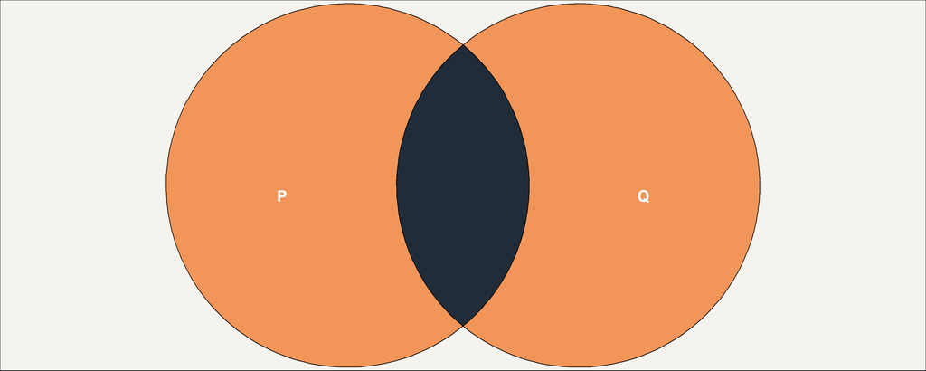

## `NOT` in Excel

- sweet relief: please open the sample workbook for this session in Excel
- have a look at the `NOT` worksheet
  - `NOT()` function inputs in the truth-table
  - example use about inhalers
    - note that `NOT()` will treat **any** number as `TRUE`, and 0 as `FALSE`

**Task**

- please add a formula to decide whether a person is a **non-user** of inhalers or not
- it should return `TRUE`/`FALSE` based on the number of inhalers used

## `AND` and `OR` in Excel

- have a look at the `AND / OR` worksheet
  - have a look at the truth-table for `AND` and `OR`
  - specifically, look at the formulas and the way they use `AND()` and `OR()`

**Task**

- in the hypertension/diabetes table, you’ve got several rows of data where each represents a person. Please write two formulas:
  - for diet and lifestyle, you’ll want to return `TRUE` if a person has either hypertension and/or diabetes
  - for statins, you’ll want to return `TRUE` is a person has both hypertension and diabetes

## IF

- unfortunately our data usually doesn’t come neatly coded into `TRUE` and `FALSE`
- that mean we’ll usually need to use our basic logical functions in combination with other functions
- `IF` is a great example of a function that helps you convert to logical values
- here’s an example formula: `=IF(B3 > 150, "Hypertension", "No hypertension")`
  - if the value in B3 is over 150, the formula returns `"Hypertension"`
  - otherwise it returns `"No hypertension"`

## IF

- this is useful in its own right, but gets even more powerful when you return logical values
- have a look at the top table on the `IF` worksheet

**Task**

- in the `IF` worksheet, there’s an incomplete table of blood pressure values
- please write a formula to return `TRUE` if those values are over 150, and `FALSE` otherwise
- there’s a named cell on this sheet called `Cutoff` - please now change that 150 in your `IF` formula to use the value of the named cell

## TRUE and FALSE are 1 and 0

- many other tools let you add up `TRUE`/`FALSE` values as if they were 1s and 0s
- this can be very useful - say, to quickly count matching values
- Excel needs a minor workaround: add `--` before a logical value to treat it as a number: `=SUM(--Table1[Hypertension?])`

## IFS

- `IFS` allows you to check for the presence of several conditions fairly concisely
- an example: `=IFS(B4 = TRUE,"High",C4 = "CRD","High", D4 > 20,"High", TRUE,"Low")`
  - read this horror as pairs of arguments, like `B4 = TRUE`, `"High"`
  - each pair contains
    - a logical test - like `B4 = TRUE`
    - a return value if that test is `TRUE` - like `"High"`
  - the final pair of arguments are a catch-all to pick up all non-matched values

## Public service announcement

- just because you can, doesn’t mean you should
- `IFS` get pathologically complicated
- pivot tables might be better for more complicated cases

## `IFNA`, `IFERROR`, and friends

- these functions are great for dealing with errors and missing values
- that’s useful, because (understatement of the decade) Excel isn’t very good at consistently dealing with errors and missing values

## `IS` and `IF` functions

- `IS****` functions detect errors and missing values and return `TRUE`/`FALSE`
- `IF****` functions detect, and then:
  - if an error is found display a message of your choice
  - otherwise just repeat the value they refer to

## What do they detect?

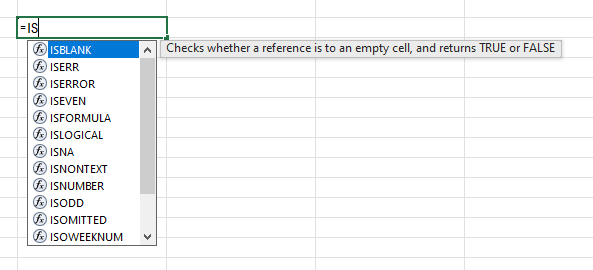

## The important ones

- BLANK = “There’s no value in that cell”
- ERROR = “This formula doesn’t work properly”
- #N/A = “[I can’t find what I was asked to find](https://support.microsoft.com/en-gb/office/how-to-correct-a-n-a-error-a9708411-f82e-4e1b-8a7e-28c28311b993)”
- ERR = “A non-N/A error has happened”

## SUMIF and COUNTIF

- basically, `IF` plus summary functions
- three simple-ish examples to see

## Real life examples

Sincere thanks and appreciation to people who volunteered formulas for this section:

- Gail Young (NHS Greater Glasgow & Clyde)
- Gail Donaldson (NHS Lanarkshire)
- Matthew Hooks (Scottish Ambulance Service)
- Susanna Kirk (NHS Fife)
- Hilary Guthrie (NHS Lothian)
- Irene Ventura (NHS Lanarkshire)
- Peter Wild (NHS Ayrshire & Arran)
- Chris Spratt (NHS National Services Scotland)

Pilot version